# WSP closed question analysis

Lizzie Jones[^1]

10/05/2021

## WSP - Analysis, stats and visualisations for closed questions

This rMarkdown explores and analyses the closed-ended questions

### About rMarkdowns

This rMarkdown document will be periodically updated and uploaded to the OneDrive folder and pushed to the WSP GitHub code repository. The primary format of this document is HTML, but this can be easily changed by changing the output (e.g. PDF, GitHub) using the ‘output’ section at the top of the document. The possible output formats are listed here: https://rmarkdown.rstudio.com/lesson-9.html.

## Sectioned analysis (in order found in questionnaire)

### Respondent knowledge

Some useful Likert plotting guides and packages: * https://cran.r-project.org/web/packages/sjPlot/vignettes/plot_likert_scales.html * https://towardsdatascience.com/how-to-plot-likert-scales-with-a-weighted-survey-in-a-dplyr-friendly-way-68df600881a * https://www.r-graph-gallery.com/202-barplot-for-likert-type-items.html

### Q2) Which of the following animals is a white stork?

```r
### Calculating sample sizes for knowledge questions table

# Selecting image of WS
final_data %>%
  dplyr::select(SurveyType, Q2_photo_recog_score, Q2_photo_recog) %>%
  dplyr::group_by(SurveyType, Q2_photo_recog) %>%
  summarise(n = n()) %>%
  mutate(Percent = (n / sum(n)*100))
```

```
## # A tibble: 12 x 4
## # Groups:   SurveyType [2]
##    SurveyType Q2_photo_recog     n Percent
##    <fct>      <fct>          <int>   <dbl>
##  1 NatRep     A                 19  1.66
##  2 NatRep     B                407 35.6
##  3 NatRep     C                 12  1.05
##  4 NatRep     D                567 49.6
##  5 NatRep     Don't know       133 11.6
##  6 NatRep     E                  5  0.437
##  7 Proactive  A                 16  0.670
##  8 Proactive  B               2124 88.9
##  9 Proactive  C                  6  0.251
## 10 Proactive  D                171  7.16
## 11 Proactive  Don't know        69  2.89
## 12 Proactive  E                  2  0.0838
```

### Q3) Is the white stork native to England?

```
## # A tibble: 6 x 4
## # Groups:   SurveyType [2]
##   SurveyType Q3_is_native     n Percent
##   <fct>      <fct>        <int>   <dbl>
## 1 NatRep     No             219    19.2
## 2 NatRep     Not sure       711    62.2
## 3 NatRep     Yes            213    18.6
## 4 Proactive  No             344    14.4
## 5 Proactive  Not sure       682    28.6
## 6 Proactive  Yes           1362    57.0
```

### Q4) Are the following statements true or false?

1. Most European white storks migrate south to Africa in the winter
2. A white stork’s wingspan can exceed 2 meters (6 feet 7 inches)
3. White storks are globally rare

```
## # A tibble: 6 x 4
## # Groups:   SurveyType [2]
##   SurveyType Q4.1_migrate     n Percent
##   <fct>      <fct>        <int>   <dbl>
## 1 NatRep     Don't know     642   56.2
## 2 NatRep     FALSE           38    3.32
## 3 NatRep     TRUE           463   40.5
## 4 Proactive  Don't know     861   36.1
## 5 Proactive  FALSE           93    3.89
## 6 Proactive  TRUE          1434   60.1
```

```
## # A tibble: 6 x 4
## # Groups:   SurveyType [2]
##   SurveyType Q4.2_wingspan     n Percent
##   <fct>      <fct>         <int>   <dbl>
## 1 NatRep     Don't know      543   47.5
## 2 NatRep     FALSE            73    6.39
## 3 NatRep     TRUE            527   46.1
## 4 Proactive  Don't know      618   25.9
## 5 Proactive  FALSE            82    3.43
## 6 Proactive  TRUE           1688   70.7
```

```
## # A tibble: 6 x 4
## # Groups:   SurveyType [2]
##   SurveyType Q4.3_globallyrare     n Percent
##   <fct>      <fct>             <int>   <dbl>
## 1 NatRep     Don't know          594   52.0
## 2 NatRep     FALSE                99    8.66
## 3 NatRep     TRUE                450   39.4
## 4 Proactive  Don't know         1036   43.4
## 5 Proactive  FALSE               697   29.2
## 6 Proactive  TRUE                655   27.4
```

### Q5) What do white storks typically eat?

[multi-select] Amphibians; Fish; Invertebrates; Reptiles; Small mammals; Bird eggs/chicks; Carrion; Food waste; Vegetation; Seeds; Fruit; Don’t know

```
## # A tibble: 24 x 5
## # Groups:   SurveyType, Diet [24]
##    SurveyType Diet                     Answer  count percent
##    <fct>      <chr>                    <chr>   <int>   <dbl>
##  1 NatRep     Q5a_amphibians_diet      Correct   228   19.9
##  2 NatRep     Q5b_birdeggs.chicks_diet Correct   142   12.4
##  3 NatRep     Q5c_carrion_diet         Correct    63    5.51
##  4 NatRep     Q5d_fish_diet            Correct   651   57.0
##  5 NatRep     Q5e_foodwaste_diet       Correct    67    5.86
##  6 NatRep     Q5f_fruit_diet           Correct    51    4.46
##  7 NatRep     Q5g_inverts_diet         Correct   256   22.4
##  8 NatRep     Q5h_reptiles_diet        Correct   137   12.0
##  9 NatRep     Q5i_seeds_diet           Correct    78    6.82
## 10 NatRep     Q5j_smallmammals_diet    Correct   141   12.3
## # … with 14 more rows
```

### Q6) What are white storks preferred feeding habitat?

[multi-select] Shallow wetlands; Grassland; Farmland; Woodland; Urban; Don’t know

```
## # A tibble: 12 x 5
## # Groups:   SurveyType, Habitat [12]
##    SurveyType Habitat               Answer count percent
##    <fct>      <chr>                 <chr>  <int>   <dbl>
##  1 NatRep     Q6a_farmland_habitat  Yes      109    9.54
##  2 NatRep     Q6b_grassland_habitat Yes      198   17.3
##  3 NatRep     Q6c_wetlands_habitat  Yes      661   57.8
##  4 NatRep     Q6d_woodland_habitat  Yes       74    6.47
##  5 NatRep     Q6e_urban_habitat     Yes       23    2.01
##  6 NatRep     Q6f_Don.tKnow_habitat Yes      342   29.9
##  7 Proactive  Q6a_farmland_habitat  Yes      712   29.8
##  8 Proactive  Q6b_grassland_habitat Yes     1159   48.5
##  9 Proactive  Q6c_wetlands_habitat  Yes     1663   69.6
## 10 Proactive  Q6d_woodland_habitat  Yes      206    8.63
## 11 Proactive  Q6e_urban_habitat     Yes       84    3.52
## 12 Proactive  Q6f_Don.tKnow_habitat Yes      363   15.2
```

### Q7) Where do white storks typically nest?

[multi-select] Trees; Roofs of buildings; Chimneys; Telegraph poles; Ground; Don’t know

```
## # A tibble: 12 x 5
## # Groups:   SurveyType, Nest [12]
##    SurveyType Nest                       Answer count percent
##    <fct>      <chr>                      <chr>  <int>   <dbl>
##  1 NatRep     Q7a_chimneys_nesting       Yes      173   15.1
##  2 NatRep     Q7b_ground_nesting         Yes      244   21.3
##  3 NatRep     Q7c_roofs_nesting          Yes      208   18.2
##  4 NatRep     Q7d_telegraphpoles_nesting Yes      106    9.27
##  5 NatRep     Q7e_trees_nesting          Yes      296   25.9
##  6 NatRep     Q7f_Don.tKnow_nesting      Yes      449   39.3
##  7 Proactive  Q7a_chimneys_nesting       Yes     1251   52.4
##  8 Proactive  Q7b_ground_nesting         Yes      106    4.44
##  9 Proactive  Q7c_roofs_nesting          Yes     1252   52.4
## 10 Proactive  Q7d_telegraphpoles_nesting Yes      978   41.0
## 11 Proactive  Q7e_trees_nesting          Yes     1784   74.7
## 12 Proactive  Q7f_Don.tKnow_nesting      Yes      200    8.38
```

## If/where seen a white stork

### Q8) Before taking this survey, had you ever seen a white stork?

[multi-select] Yes, in the wild; Yes, in captivity; Yes, in pictures/videos; No; Not sure

```
##   Q8_wild_seen Q8_captivity_seen Q8_pictures_video Q8_No Q8_NotSure SurveyType
## 1            0                 0                 1     0          0  Proactive
## 2            1                 0                 0     0          0  Proactive
## 3            1                 0                 0     0          0  Proactive
## 4            1                 1                 0     0          0  Proactive
## 5            1                 1                 0     0          0  Proactive
## 6            0                 0                 1     0          0  Proactive
##   UniqueID_all
## 1            1
## 2            2
## 3            3
## 4            4
## 5            5
## 6            6
```

```
## # A tibble: 11 x 5
## # Groups:   SurveyType, Q8_option [11]
##    SurveyType Q8_option         Answer     n Percent
##    <fct>      <chr>              <int> <int>   <dbl>
##  1 NatRep     Q8_captivity_seen      1    83  7.26
##  2 NatRep     Q8_No                  1   523 45.8
##  3 NatRep     Q8_NotSure             1   163 14.3
##  4 NatRep     Q8_pictures_video      1   285 24.9
##  5 NatRep     Q8_wild_seen           1   156 13.6
##  6 Proactive  Q8_captivity_seen      1   367 15.4
##  7 Proactive  Q8_No                  1   339 14.2
##  8 Proactive  Q8_NotSure             1   119  4.98
##  9 Proactive  Q8_pictures_video      1   827 34.6
## 10 Proactive  Q8_wild_seen           1  1286 53.9
## 11 Proactive  UniqueID_all           1     1  0.0419
```

```
## # A tibble: 8 x 4
## # Groups:   SurveyType [2]
##   SurveyType Q8.WhereSeen     n Percent
##   <fct>      <fct>        <int>   <dbl>
## 1 NatRep     Both            10   0.875
## 2 NatRep     OutsideUK       92   8.05
## 3 NatRep     UK              54   4.72
## 4 NatRep     <NA>           987  86.4
## 5 Proactive  Both           289  12.1
## 6 Proactive  OutsideUK      579  24.2
## 7 Proactive  UK             418  17.5
## 8 Proactive  <NA>          1102  46.1
```

### Q9) Before taking this survey, had you ever heard of the White Stork Project and its efforts to reintroduce white storks to southern England?

[options] Yes, No, Not sure

```
## # A tibble: 6 x 4
## # Groups:   SurveyType [2]
##   SurveyType Q9_heard     n Percent
##   <fct>      <fct>    <int>   <dbl>
## 1 NatRep     No         988   86.4
## 2 NatRep     Not sure    71    6.21
## 3 NatRep     Yes         84    7.35
## 4 Proactive  No         673   28.2
## 5 Proactive  Not sure    69    2.89
## 6 Proactive  Yes       1646   68.9
```

## Q10) How much do you feel you know about the white stork reintroduction currently taking place in southern England?

Nothing; I have heard something but don’t know much; I know something about it; I know a lot about it; I am involved in the effort

```
## # A tibble: 10 x 4
## # Groups:   SurveyType [2]
##    SurveyType Q10_project_knowledge                          n Percent
##    <fct>      <fct>                                      <int>   <dbl>
##  1 NatRep     I am involved in the effort                    7   0.612
##  2 NatRep     I have heard something but don’t know much   181  15.8
##  3 NatRep     I know a lot about it                         10   0.875
##  4 NatRep     I know something about it                     64   5.60
##  5 NatRep     Nothing                                      881  77.1
##  6 Proactive  I am involved in the effort                   15   0.628
##  7 Proactive  I have heard something but don’t know much   729  30.5
##  8 Proactive  I know a lot about it                        172   7.20
##  9 Proactive  I know something about it                    906  37.9
## 10 Proactive  Nothing                                      566  23.7
```

### Q10a) [if selected any option apart from “Nothing”] Where have you heard about the white stork reintroduction project?

[multi-select] White Stork Project website; Social media; TV/Radio; Newspaper; Email; Magazine; Leaflet; Talk by a project spokesperson; Visiting Knepp Estate; Word of mouth; Other

```
## # A tibble: 23 x 5
## # Groups:   SurveyType, Q10_cursource [23]
##    SurveyType Q10_cursource      Answer     n Percent
##    <fct>      <chr>              <chr>  <int>   <dbl>
##  1 NatRep     Q10a_Email         1         18    6.87
##  2 NatRep     Q10a_Leaflet       1         12    4.58
##  3 NatRep     Q10a_Magazine      1         32   12.2
##  4 NatRep     Q10a_Newspaper     1         45   17.2
##  5 NatRep     Q10a_Other         1         12    4.58
##  6 NatRep     Q10a_Socialmedia   1         66   25.2
##  7 NatRep     Q10a_spokesperson  1          7    2.67
##  8 NatRep     Q10a_TV.Radio      1         82   31.3
##  9 NatRep     Q10a_VisitingKnepp 1          5    1.91
## 10 NatRep     Q10a_Wordofmouth   1         36   13.7
## # … with 13 more rows
```

### Q10b) How would you like information about the ongoing reintroduction to be communicated to you?

[multi-select] White Stork Project website; Social media; TV/Radio; Newspaper; Email; Magazine; Leaflet; Talk by a project spokesperson; Not interested; Other

```
## # A tibble: 20 x 5
## # Groups:   SurveyType, Q10_prefsource [20]
##    SurveyType Q10_prefsource     Answer     n Percent
##    <fct>      <chr>              <chr>  <int>   <dbl>
##  1 NatRep     Q10b_Email         1        317 27.7
##  2 NatRep     Q10b_Leaflet       1        132 11.5
##  3 NatRep     Q10b_Magazine      1        113  9.89
##  4 NatRep     Q10b_Newspaper     1        198 17.3
##  5 NatRep     Q10b_NotInterested 1        197 17.2
##  6 NatRep     Q10b_Other         1          1  0.0875
##  7 NatRep     Q10b_Socialmedia   1        319 27.9
##  8 NatRep     Q10b_spokesperson  1         59  5.16
##  9 NatRep     Q10b_TV.Radio      1        363 31.8
## 10 NatRep     Q10b_WSPwebsite    1        421 36.8
## 11 Proactive  Q10b_Email         1        808 33.8
## 12 Proactive  Q10b_Leaflet       1        171  7.16
## 13 Proactive  Q10b_Magazine      1        325 13.6
## 14 Proactive  Q10b_Newspaper     1        508 21.3
## 15 Proactive  Q10b_NotInterested 1        111  4.65
## 16 Proactive  Q10b_Other         1         36  1.51
## 17 Proactive  Q10b_Socialmedia   1       1542 64.6
## 18 Proactive  Q10b_spokesperson  1        458 19.2
## 19 Proactive  Q10b_TV.Radio      1        903 37.8
## 20 Proactive  Q10b_WSPwebsite    1       1365 57.2
```

### Q12-14) How much do you agree or disagree with the following statements?

- White storks symbolise the beauty of nature.
- White storks play an important role in their environment.
- Reintroduced white storks may have a negative impact on my life.
- I do not want white storks living near me.
- White storks in England could benefit the tourism industry where they’re found.
- I would find it exciting to see white storks in the wild in England.
- White storks symbolise hope, rebirth and new life.
- Money spent reintroducing white storks would be better spent elsewhere.
- White storks might be detrimental to local wildlife.
- There is no need to reintroduce the white stork to England as it is common throughout mainland Europe
- I think white storks are useless birds.
- White storks are part of our cultural and natural heritage
- The reintroduced white stork can help people (re)connect with the natural world.
- The countryside will be worse off with white storks around.
- Overall, I support efforts that aim to reintroduce the UK’s lost species and restore its natural systems.

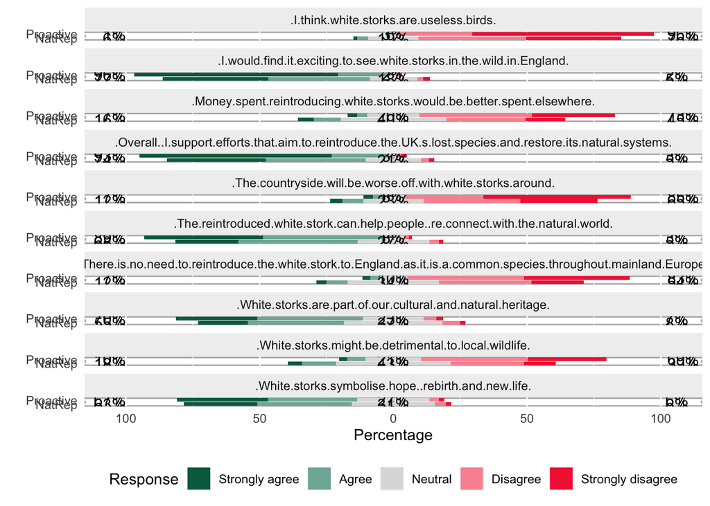

```
## # A tibble: 3,651 x 5
## # Groups:   SurveyType, Attitude_questions [22]
##    SurveyType Attitude_questions                        Answer         n Percent
##    <fct>      <chr>                                     <chr>      <int>   <dbl>
##  1 NatRep     Q13.1..I.would.find.it.exciting.to.see.w… Agree        420   36.7
##  2 NatRep     Q13.1..I.would.find.it.exciting.to.see.w… Disagree      25    2.19
##  3 NatRep     Q13.1..I.would.find.it.exciting.to.see.w… Don't know    36    3.15
##  4 NatRep     Q13.1..I.would.find.it.exciting.to.see.w… Neutral      196   17.1
##  5 NatRep     Q13.1..I.would.find.it.exciting.to.see.w… Strongly …   437   38.2
##  6 NatRep     Q13.1..I.would.find.it.exciting.to.see.w… Strongly …    29    2.54
##  7 NatRep     Q13.2..White.storks.symbolise.hope..rebi… Agree        380   33.2
##  8 NatRep     Q13.2..White.storks.symbolise.hope..rebi… Disagree      45    3.94
##  9 NatRep     Q13.2..White.storks.symbolise.hope..rebi… Don't know    72    6.30
## 10 NatRep     Q13.2..White.storks.symbolise.hope..rebi… Neutral      332   29.0
## # … with 3,641 more rows
```

### Q17) Which (if any) methods of white stork project management would you support?

[multi-select] Monitoring nests; Providing places for storks to nest; Discouraging nest building; Nest removal; Tracking movements of individual storks;Public engagement and outreach; Providing supplementary food; Compensation for damage caused by stork activity; Population management by moving storks to other locations; Population management by culling; No management will be necessary; Don’t know; Other

```
##   Q17.1_Nest_monitoring Q17.2_Nesting_platforms Q17.3_Discouragenestbuilding
## 1                     1                       1                            0
## 2                     0                       0                            0
## 3                     1                       1                            0
## 4                     1                       1                            0
## 5                     1                       1                            1
## 6                     0                       0                            0
##   Q17.4_Nest_removal Q17.5_Tracking Q17.6_Public_engagement
## 1                  0              1                       1
## 2                  0              0                       0
## 3                  0              1                       1
## 4                  0              1                       1
## 5                  0              1                       1
## 6                  0              0                       0
##   Q17.7_Supplementary_food Q17.8_compensation_storkdamage
```

[output cut: 20 more lines]

```
## # A tibble: 26 x 5
## # Groups:   SurveyType, Management_options [26]
##    SurveyType Management_options           Answer     n Percent
##    <fct>      <chr>                         <int> <int>   <dbl>
##  1 NatRep     Q17_11.management.not.needed      1    50   4.37
##  2 NatRep     Q17.1_Nest_monitoring             1   587  51.4
##  3 NatRep     Q17.10_Culling                    1    49   4.29
##  4 NatRep     Q17.12_Don.tknow                  1   302  26.4
##  5 NatRep     Q17.13_other                      1     3   0.262
##  6 NatRep     Q17.2_Nesting_platforms           1   576  50.4
##  7 NatRep     Q17.3_Discouragenestbuilding      1    41   3.59
##  8 NatRep     Q17.4_Nest_removal                1    40   3.50
##  9 NatRep     Q17.5_Tracking                    1   475  41.6
## 10 NatRep     Q17.6_Public_engagement           1   371  32.5
## # … with 16 more rows
```

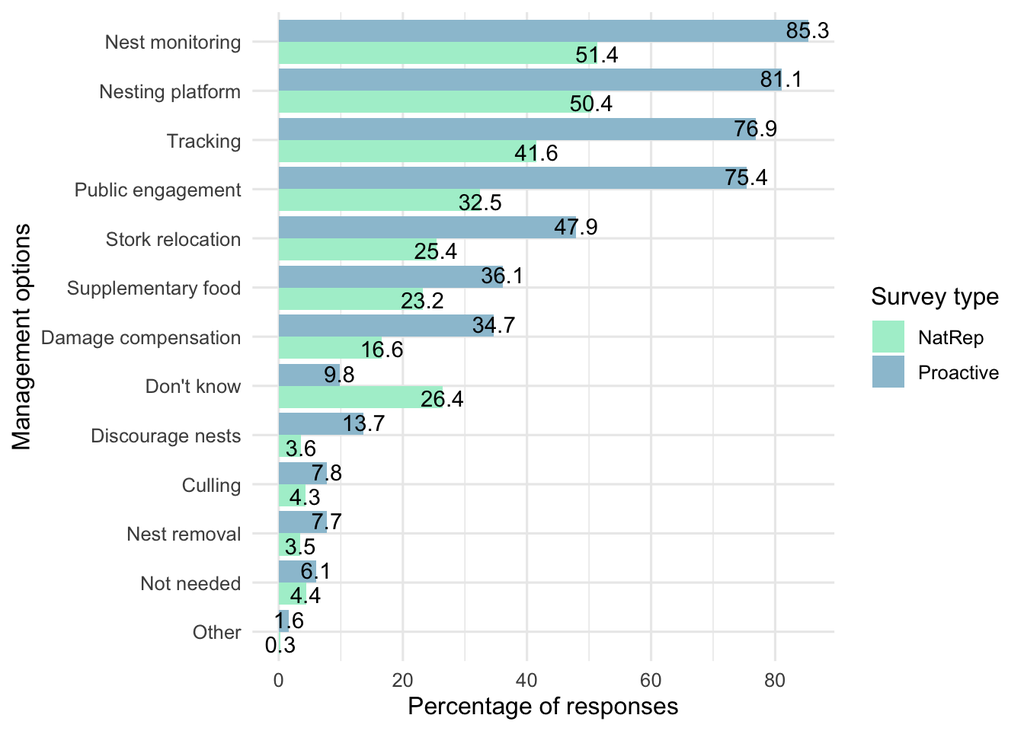

### Q18) In an average week, how many days do you spend more than 1 hour outside in green and natural spaces?

[options] None; 1-2 days; 3-4 days; 5-6 days; Every day - 7 days

```
## # A tibble: 10 x 5
## # Groups:   SurveyType, Frequency [2]
##    SurveyType Frequency                      Answer                n Percent
##    <fct>      <chr>                          <chr>             <int>   <dbl>
##  1 NatRep     Frequency of nature experience 1-2 days            459   40.2
##  2 NatRep     Frequency of nature experience 3-4 days            236   20.6
##  3 NatRep     Frequency of nature experience 5-6 days            133   11.6
##  4 NatRep     Frequency of nature experience Every day, 7 days   125   10.9
##  5 NatRep     Frequency of nature experience None                190   16.6
##  6 Proactive  Frequency of nature experience 1-2 days            523   21.9
##  7 Proactive  Frequency of nature experience 3-4 days            612   25.6
##  8 Proactive  Frequency of nature experience 5-6 days            495   20.7
##  9 Proactive  Frequency of nature experience Every day, 7 days   721   30.2
## 10 Proactive  Frequency of nature experience None                 37    1.55
```

### Q18a) Which of these recreation activities do you do while you are outside in green and natural spaces?

[multi-select] Walking (with dog); Walking (without dog); Running/cycling; Golf; Picnic; Horse riding; Bird/wildlife watching; Photography; Camping; Fishing; Shooting/hunting; Water sports/swimming; Gardening; I don’t spend my free time in green and natural spaces; Other

```
##   Q18a.golf Q18a.picnic Q18a.horse.riding Q18a.bird.wildlife.watching
## 1         0           0                 0                           0
## 2         0           1                 0                           1
## 3         0           0                 0                           1
## 4         0           0                 0                           1
## 5         0           0                 0                           1
## 6         0           1                 0                           0
##   Q18a.photography Q18a.camping Q18a.fishing Q18a.shooting.hunting
## 1                0            0            0                     0
## 2                0            0            0                     0
## 3                0            0            0                     0
## 4                0            0            0                     0
## 5                1            0            0                     0
## 6                0            0            0                     0
##   Q18a.water.sports.swimming Q18a.gardening
## 1                          0              0
## 2                          0              1
## 3                          0              0
## 4                          0              1
## 5                          0              1
## 6                          0              1
##   Q18a.don.t.spend.free.time.in.green.natural.spaces
## 1                                                  0
## 2                                                  0
## 3                                                  0
## 4                                                  0
## 5                                                  0
## 6                                                  0
```

```
## # A tibble: 22 x 5
## # Groups:   SurveyType, Activities [22]
##    SurveyType Activities        Answer     n Percent
##    <fct>      <chr>              <int> <int>   <dbl>
##  1 NatRep     Wildlife watching      1   176   15.4
##  2 NatRep     Camping                1    70    6.12
##  3 NatRep     I don't                1    90    7.87
##  4 NatRep     Fishing                1    49    4.29
##  5 NatRep     Gardening              1   444   38.8
##  6 NatRep     Golf                   1    47    4.11
##  7 NatRep     Horse riding           1    17    1.49
##  8 NatRep     Photography            1   177   15.5
##  9 NatRep     Picnic                 1   156   13.6
## 10 NatRep     Shooting/hunting       1    15    1.31
## # … with 12 more rows
```

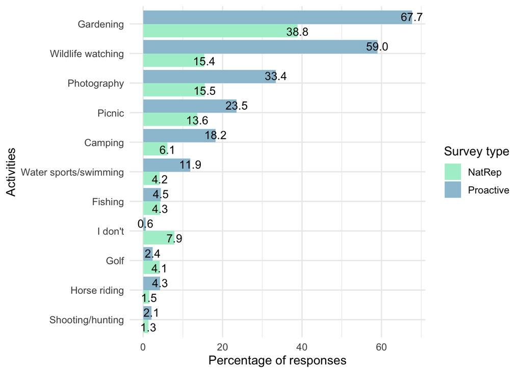

### Q19) How much do you agree or disagree with the following statements?

- I find being in nature really amazing
- Spending time in nature is very important to me
- Being in nature makes me very happy
- I always find beauty in nature
- I always treat nature with respect
- I feel part of nature

[options] Completely disagree = 1, Strongly disagree = 2, Disagree = 3, Neither agree or disagree = 4, Agree = 5, Strongly agree = 6, Completely agree = 7

```
## [1] "Agree"                     "Completely agree"
## [3] "Completely disagree"       "Disagree"
## [5] "Neither agree or disagree" "Strongly agree"
## [7] "Strongly disagree"
```

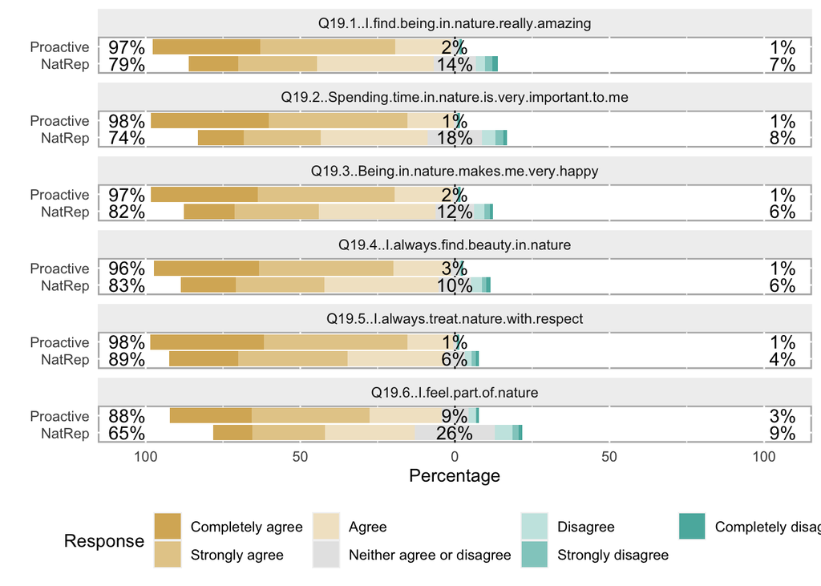

```
##   Q19.1..I.find.being.in.nature.really.amazing
## 1                               Strongly agree
## 2                             Completely agree
## 3                             Completely agree
## 4                               Strongly agree
## 5                             Completely agree
## 6                               Strongly agree
##   Q19.2..Spending.time.in.nature.is.very.important.to.me
## 1                                                  Agree
## 2                                       Completely agree
## 3                                       Completely agree
## 4                                         Strongly agree
## 5                                       Completely agree
## 6                                         Strongly agree
##   Q19.3..Being.in.nature.makes.me.very.happy
```

[output cut: 27 more lines]

```
## # A tibble: 3,615 x 5
## # Groups:   SurveyType, NCI_questions [14]
##    SurveyType NCI_questions                       Answer               n Percent
##    <fct>      <chr>                               <chr>            <int>   <dbl>
##  1 NatRep     Q19.1..I.find.being.in.nature.real… Agree              433   37.9
##  2 NatRep     Q19.1..I.find.being.in.nature.real… Completely agree   183   16.0
##  3 NatRep     Q19.1..I.find.being.in.nature.real… Completely disa…    22    1.92
##  4 NatRep     Q19.1..I.find.being.in.nature.real… Disagree            34    2.97
##  5 NatRep     Q19.1..I.find.being.in.nature.real… Neither agree o…   155   13.6
##  6 NatRep     Q19.1..I.find.being.in.nature.real… Strongly agree     290   25.4
##  7 NatRep     Q19.1..I.find.being.in.nature.real… Strongly disagr…    26    2.27
##  8 NatRep     Q19.2..Spending.time.in.nature.is.… Agree              396   34.6
##  9 NatRep     Q19.2..Spending.time.in.nature.is.… Completely agree   170   14.9
## 10 NatRep     Q19.2..Spending.time.in.nature.is.… Completely disa…    14    1.22
## # … with 3,605 more rows
```

### Q20) In relation to the UK, how concerned are you about:

- Damage to the natural environment
- The consequences of a loss of variety of wildlife

[options] Not at all concerned = 1, Not very concerned = 2, Neither concerned or unconcerned = 3, Concerned = 4, Extremely concerned = 5

```
## [1] "Concerned"                        "Extremely concerned"
## [3] "Neither concerned or unconcerned" "Not at all concerned"
## [5] "Not very concerned"
```

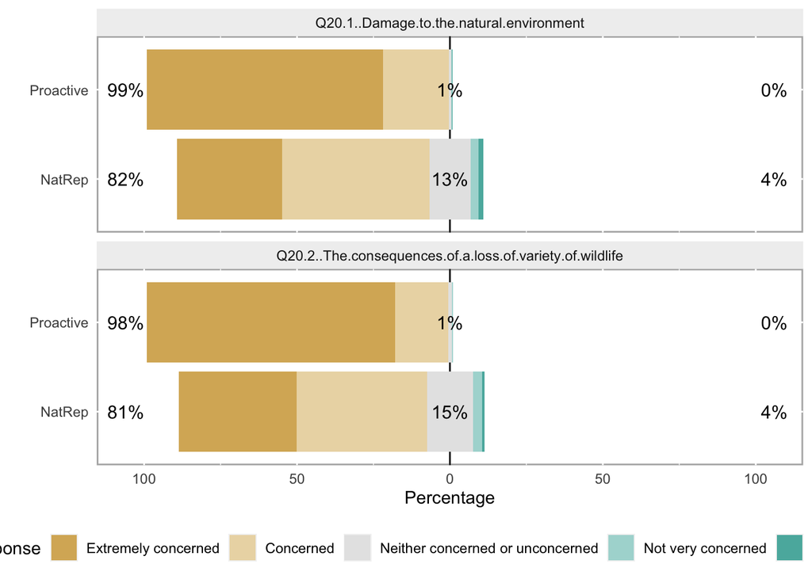

### Q21) How often do you do the actions below when you have the opportunity?

- When I see litter, I pick it up.
- I vote for nature or wildlife conservation friendly legislation in local or national referendums/votes/etc.
- I get in touch with local authorities on nature conservation issues.
- I vote for parties/ candidates with strong pro-nature conservation policies in elections.

[Options] Never = 1, Rarely = 2, Occasionally = 3, Sometimes = 4, Frequently = 5, Very frequently = 6, Always = 7

```
## [1] "Always"          "Frequently"      "Never"           "Occasionally"
## [5] "Rarely"          "Sometimes"       "Very Frequently"
```

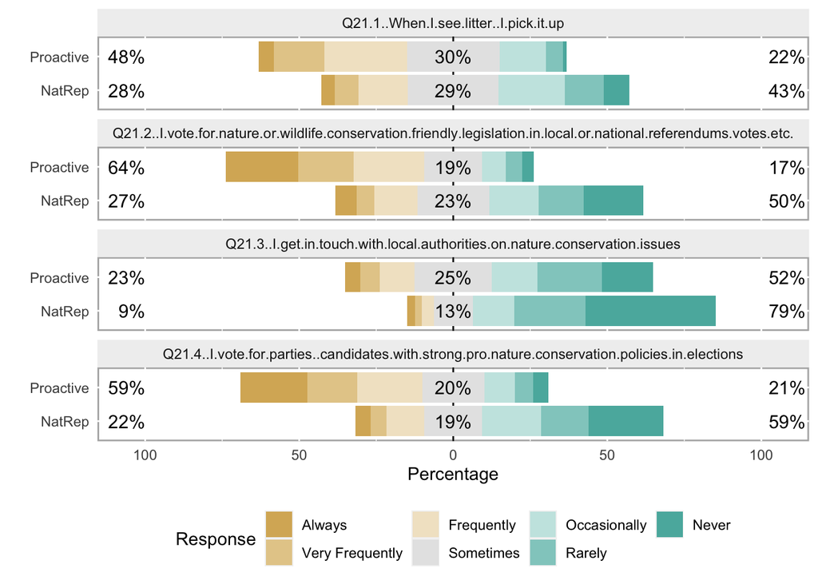

### Q23) Thinking about your daily life, how much do you agree or disagree with the following statements?

- I pay attention to birds wherever I go.
- I can identify common birds in my area.
- Seeing a new bird fills me with excitement.
- I am not interested in birds.

[Options] Strongly Disagree = 1, Disagree = 2, Neutral = 3, Agree = 4, Strongly Agree = 5. [†reverse scored]

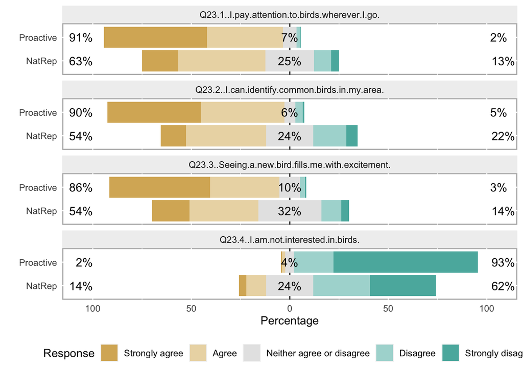

[^1]: University of Brighton, l.jones4@brighton.ac.uk